# Optimización de portafolios (Media-Varianza) — repaso con teoría

## Configuración inicial

```r
if (!require("pacman")) install.packages("pacman")
pacman::p_load(tidyverse, xts, quantmod, TTR,
               stats, zoo, PerformanceAnalytics, PortfolioAnalytics, ROI,
               ROI.plugin.quadprog, ROI.plugin.glpk, readr, CVXR, scales)
options(scipen = 999)
```

# Parte 1 — Descarga de precios y retornos

**Qué hace**: descarga los precios de cierre ajustados de 20 acciones grandes de NASDAQ/NYSE (leídas de un CSV con la lista de tickers) y calcula sus retornos mensuales continuos.

**Por qué (teoría)**: la optimización de Markowitz necesita, para cada activo, un retorno esperado y una matriz de covarianzas — ambos se estiman aquí a partir del histórico de retornos (2020-12-31 en adelante). Un universo de 20 activos es lo bastante grande para que la diversificación tenga sentido, sin ser tan grande que la matriz de covarianzas se vuelva difícil de manejar a mano.

```r
free_rate <- 0.009489

companies <- read_csv(file = "https://raw.githubusercontent.com/salas317/Data/main/NASDAQ_NYSE.csv",
                      show_col_types = FALSE)[1:20,]

activos <- companies$`Ticker Symbol`
activos
```

```
##  [1] "NVDA"  "AAPL"  "GOOGL" "MSFT"  "AMZN"  "AVGO"  "META"  "TSLA"  "LLY"
## [10] "BRK.A" "MU"    "JPM"   "WMT"   "AMD"   "V"     "JNJ"   "MA"    "INTC"
## [19] "ABBV"  "CSCO"
```

## Primer intento (falla a propósito)

**Qué hace**: intenta descargar los 20 tickers tal como vienen en el CSV — y falla.

**Por qué (el hallazgo real)**: uno de los tickers es `BRK.A` (Berkshire Hathaway clase A), pero Yahoo Finance identifica ese activo como `BRK-A` (guion, no punto) — la consulta a `BRK.A` devuelve 404, y como `getSymbols` sigue de largo con los 19 activos que sí encontró, el `colnames<-` posterior falla porque hay 20 nombres para 19 columnas. Es un recordatorio de que **el nombre de un ticker no es universal entre proveedores de datos** — Bloomberg, Yahoo y el propio NYSE pueden usar convenciones distintas para el mismo activo.

```r
precios <- quantmod::getSymbols(activos, src = 'yahoo',
                                from = "2020-12-31",
                                periodicity = "daily",
                                auto.assign = T,
                                warnings = F) %>%
  purrr::map(~quantmod::Ad(get(.))) %>%
  purrr::reduce(merge.xts) %>%
  `colnames<-`(activos)
```

```
## Error in `dimnames<-.xts`:
## ! la longitud de 'dimnames' [2] no es igual a la extensión del arreglo
```

## Corrección y descarga real

```r
activos <- activos %>% gsub(pattern = "BRK.A", x = ., replacement = "BRK-A")

precios <- quantmod::getSymbols(activos, src = 'yahoo',
                                from = "2020-12-31",
                                periodicity = "daily",
                                auto.assign = T,
                                warnings = F) %>%
  purrr::map(~quantmod::Ad(get(.))) %>%
  purrr::reduce(merge.xts) %>%
  `colnames<-`(activos)

retornos_mes <- precios %>%
  xts::to.monthly(indexAt = "lastof", OHLC = FALSE) %>%
  TTR::ROC(type = "continuous",
           na.pad = F)

tail(retornos_mes[, 1:5])
```

```
##                    NVDA        AAPL       GOOGL        MSFT         AMZN
## 2026-04-30  0.118996500  0.02677881  0.21119368  0.03758003  0.232848676
## 2026-05-31  0.191170028  0.20760924  0.27963402  0.19798192  0.261954243
## 2026-06-30  0.003766999  0.06518292 -0.07335488 -0.08693228 -0.106257996
## 2026-07-31 -0.049296289 -0.01014548 -0.06517257  0.03165429  0.003467127
## 2026-08-31  0.098399519  0.09161898 -0.05173963  0.30933159  0.086098372
## 2026-09-30  0.132168449  0.09204065 -0.03765197  0.09332582 -0.098315624
```

# Parte 2 — ¿Cuál activo tiene mejor prima por unidad de riesgo?

**Qué hace**: calcula el Sharpe Ratio de cada activo individual con tres medidas de riesgo distintas en el denominador — desviación estándar, VaR(99%) y Pérdida Esperada(99%).

**Por qué (teoría)**: el Sharpe Ratio (retorno sobre riesgo) es la forma más directa de comparar activos con perfiles de riesgo distintos — un activo con más retorno absoluto no necesariamente es “mejor” si su riesgo también es mucho más alto. Usar tres medidas de riesgo distintas muestra si el ranking de activos cambia según cómo se defina “riesgo” (dispersión total vs. solo la cola de pérdidas).

```r
PerformanceAnalytics::SharpeRatio(R = retornos_mes, Rf = 0, FUN = "StdDev")
```

```
##                                   NVDA      AAPL     GOOGL      MSFT
## Sharpe Ratio (Rf=0%, p=95%): 0.3369583 0.1606686 0.1066253 0.1595085
##                                     AMZN      AVGO      META         TSLA
## Sharpe Ratio (Rf=0%, p=95%): -0.02000862 0.1338535 0.1085155 -0.001333908
##                                    LLY     BRK-A         MU         JPM
## Sharpe Ratio (Rf=0%, p=95%): 0.3174983 0.1532868 -0.0507801 0.006679793
##                                      WMT      AMD          V        JNJ
## Sharpe Ratio (Rf=0%, p=95%): -0.01797561 0.202369 0.03750033 0.03555948
##                                     MA       INTC      ABBV       CSCO
## Sharpe Ratio (Rf=0%, p=95%): 0.2409044 -0.0357147 0.3472086 0.01085994
```

```r
PerformanceAnalytics::SharpeRatio(R = retornos_mes, Rf = 0, FUN = "VaR", p = 0.99)
```

[output not shown]

[output not shown]

[output not shown]

[output not shown]

```
##                                  NVDA       AAPL      GOOGL       MSFT
## VaR Sharpe Ratio (Rf=0%, p=99%):   NA 0.04423575 0.02263259 0.05445014
##                                          AMZN       AVGO       META
## VaR Sharpe Ratio (Rf=0%, p=99%): -0.004164138 0.03683349 0.04147777
##                                           TSLA        LLY BRK-A         MU
## VaR Sharpe Ratio (Rf=0%, p=99%): -0.0004991288 0.09024772    NA -0.7239243
##                                          JPM         WMT       AMD           V
## VaR Sharpe Ratio (Rf=0%, p=99%): 0.004534304 -0.02047264 0.1366455 0.008870765
##                                          JNJ        MA        INTC      ABBV
## VaR Sharpe Ratio (Rf=0%, p=99%): 0.008645715 0.1050213 -0.01359814 0.1996656
##                                         CSCO
## VaR Sharpe Ratio (Rf=0%, p=99%): 0.003837006
```

```r
PerformanceAnalytics::SharpeRatio(R = retornos_mes, Rf = 0, FUN = "ES", p = 0.99)
```

[output not shown]

[output not shown]

[output not shown]

[output not shown]

[output not shown]

[output not shown]

[output not shown]

[output not shown]

```
##                                      NVDA       AAPL      GOOGL       MSFT
## ES Sharpe Ratio (Rf=0%, p=99%): 0.1197845 0.04423575 0.02263259 0.04918528
##                                         AMZN       AVGO       META
## ES Sharpe Ratio (Rf=0%, p=99%): -0.004164138 0.03683349 0.03230818
##                                          TSLA        LLY BRK-A          MU
## ES Sharpe Ratio (Rf=0%, p=99%): -0.0004048315 0.09024772    NA -0.05804965
##                                         JPM          WMT       AMD           V
## ES Sharpe Ratio (Rf=0%, p=99%): 0.004534304 -0.004802001 0.1366455 0.005780772
##                                         JNJ         MA        INTC      ABBV
## ES Sharpe Ratio (Rf=0%, p=99%): 0.005063322 0.08175055 -0.01359814 0.1503112
##                                        CSCO
## ES Sharpe Ratio (Rf=0%, p=99%): 0.002744643
```

# Parte 3 — Especificación del portafolio

**Qué hace**: define el “objeto portafolio” de `PortfolioAnalytics` — el universo de activos y las restricciones que debe cumplir cualquier combinación de pesos que se proponga.

**Por qué (teoría)**: antes de optimizar hace falta declarar el espacio de soluciones válidas. Las dos restricciones más básicas de un portafolio real son:

- **`full_investment`**: los pesos deben sumar exactamente 1 (se invierte todo el capital, nada se queda en efectivo).
- **`long_only`**: ningún peso puede ser negativo (no se permite venta en corto).

```r
init.portfolio <- PortfolioAnalytics::portfolio.spec(assets = activos,
                                                     name = "Portafolio inicial")

init.portfolio <- PortfolioAnalytics::add.constraint(portfolio = init.portfolio,
                                                     type = "full_investment")

init.portfolio <- PortfolioAnalytics::add.constraint(portfolio = init.portfolio,
                                                     type = "long_only")

print(init.portfolio)
```

```
## PortfolioAnalytics Portfolio Specification
##
## Call:
## PortfolioAnalytics::portfolio.spec(assets = activos, name = "Portafolio inicial")
##
## Number of assets: 20
## Asset Names
##  [1] "NVDA"  "AAPL"  "GOOGL" "MSFT"  "AMZN"  "AVGO"  "META"  "TSLA"  "LLY"
## [10] "BRK-A"
## More than 10 assets, only printing the first 10
##
## Constraints
## Enabled constraint types
##      - full_investment
##      - long_only
```

# Parte 4 — Frontera eficiente

**Qué hace**: calcula 100 portafolios óptimos a lo largo de la frontera eficiente — para cada nivel de riesgo, el portafolio con el mayor retorno posible (o, de forma equivalente, para cada nivel de retorno, el de menor riesgo).

**Por qué (teoría)**: la frontera eficiente es el resultado central de Markowitz (1952) — de todos los portafolios posibles, solo los que están sobre esa curva son “eficientes”; cualquier punto por debajo está dominado por otro portafolio con el mismo riesgo pero más retorno.

```r
meansd.eff <- PortfolioAnalytics::create.EfficientFrontier(R = retornos_mes,
                                                           portfolio = init.portfolio,
                                                           type = 'mean-StdDev',
                                                           n.portfolios = 100)
```

## Evolución de los pesos a lo largo de la frontera

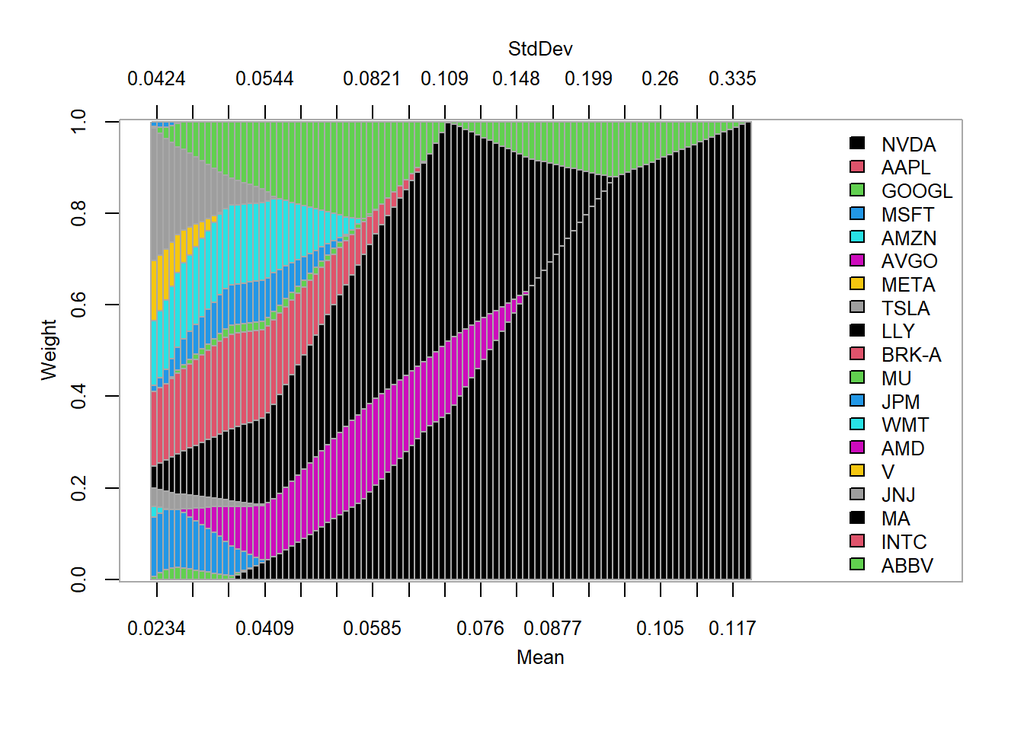

```r
PortfolioAnalytics::chart.EF.Weights(object = meansd.eff,
                 match.col = "StdDev")
```

## Frontera sin activo libre de riesgo

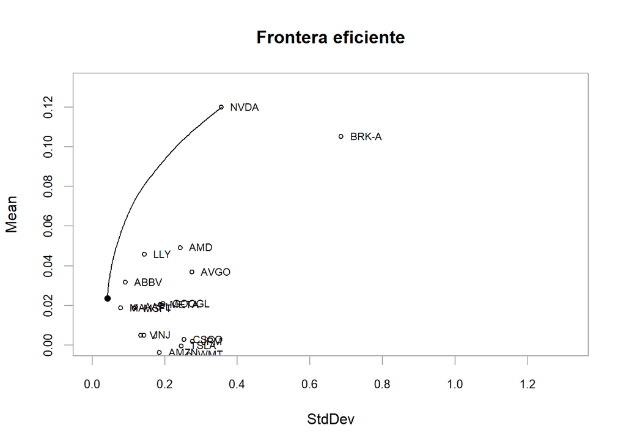

```r
PortfolioAnalytics::chart.EfficientFrontier(meansd.eff,
                                            match.col = 'StdDev',
                                            type = 'l',
                                            rf=NULL,
                                            main = "Frontera eficiente",
                                            cex.assets = 0.7)
```

## Frontera con activo libre de riesgo

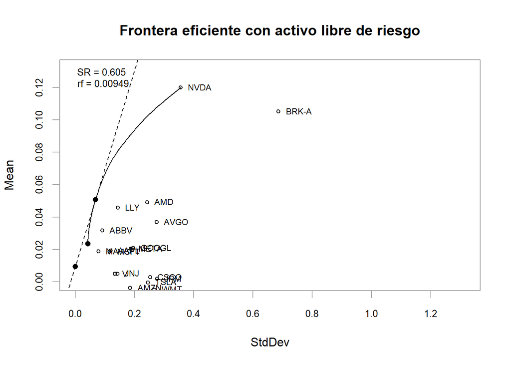

```r
PortfolioAnalytics::chart.EfficientFrontier(meansd.eff,
                                            match.col = 'StdDev',
                                            type = 'l',
                                            rf = free_rate,
                                            main = "Frontera eficiente con activo libre de riesgo",
                                            cex.assets = 0.7)
```

# Parte 5 — Cuatro objetivos de optimización

**Por qué (teoría)**: “optimizar un portafolio” no es un único problema — depende de qué se le pida al optimizador. Se resuelven acá cuatro variantes clásicas, todas sobre el mismo universo de 20 activos y las mismas restricciones (`full_investment` + `long_only`).

## 5.1 — Minimizar el riesgo, sin importar el retorno

```r
risk.portfolio <- PortfolioAnalytics::add.objective(portfolio = init.portfolio,
                                                    type = "risk",
                                                    name = "StdDev")

opt.sd <- PortfolioAnalytics::optimize.portfolio(R = retornos_mes,
                                                 portfolio = risk.portfolio,
                                                 optimize_method = "ROI",
                                                 trace = T)
opt.sd
```

```
## PortfolioAnalytics Optimization
##
## Call:
## PortfolioAnalytics::optimize.portfolio(R = retornos_mes, portfolio = risk.portfolio,
##     optimize_method = "ROI", trace = T)
##
## Optimal Weights:
##   NVDA   AAPL  GOOGL   MSFT   AMZN   AVGO   META   TSLA    LLY  BRK-A     MU
## 0.0000 0.0000 0.0060 0.1305 0.0232 0.0000 0.0000 0.0401 0.0485 0.1631 0.0000
##    JPM    WMT    AMD      V    JNJ     MA   INTC   ABBV   CSCO
## 0.0119 0.1422 0.0000 0.1322 0.2884 0.0000 0.0000 0.0040 0.0099
##
## Objective Measure:
##  StdDev
## 0.04241
```

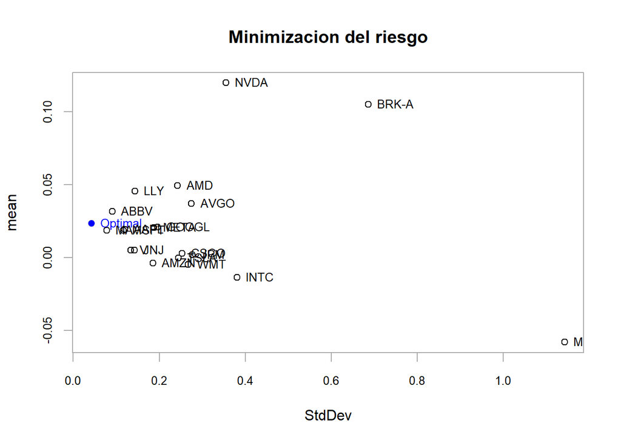

```r
PortfolioAnalytics::chart.RiskReward(opt.sd,
                                     risk.col = "StdDev",
                                     return.col = "mean",
                                     chart.assets = TRUE,
                                     rp = F,
                                     main = "Minimizacion del riesgo")
```

Este es el extremo izquierdo de la frontera eficiente — el portafolio de **mínima varianza global**.

## 5.2 — Maximizar el retorno, sin importar el riesgo

```r
mean.portfolio <- PortfolioAnalytics::add.objective(portfolio = init.portfolio,
                                                    type = "return",
                                                    name = "mean")

opt.mean <- PortfolioAnalytics::optimize.portfolio(R = retornos_mes,
                                                   portfolio = mean.portfolio,
                                                   optimize_method = "ROI",
                                                   trace = T)
opt.mean
```

```
## PortfolioAnalytics Optimization
##
## Call:
## PortfolioAnalytics::optimize.portfolio(R = retornos_mes, portfolio = mean.portfolio,
##     optimize_method = "ROI", trace = T)
##
## Optimal Weights:
##  NVDA  AAPL GOOGL  MSFT  AMZN  AVGO  META  TSLA   LLY BRK-A    MU   JPM   WMT
##     1     0     0     0     0     0     0     0     0     0     0     0     0
##   AMD     V   JNJ    MA  INTC  ABBV  CSCO
##     0     0     0     0     0     0     0
##
## Objective Measure:
##   mean
## 0.1198
```

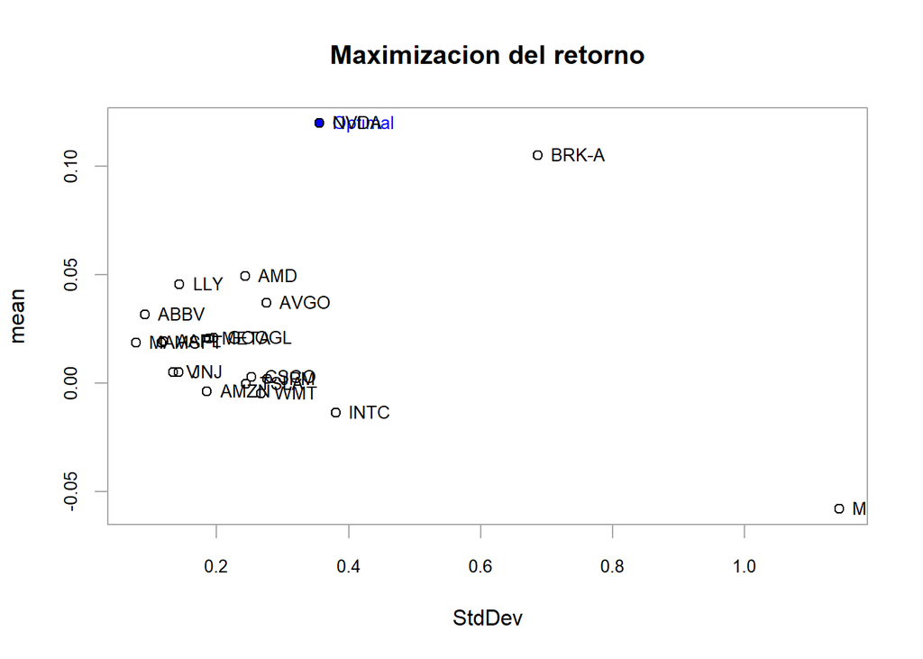

```r
PortfolioAnalytics::chart.RiskReward(opt.mean,
                                     risk.col = "StdDev",
                                     return.col = "mean",
                                     chart.assets = TRUE,
                                     rp = F,
                                     main = "Maximizacion del retorno")
```

**Nota**: sin ninguna restricción que penalice la concentración, este objetivo casi siempre termina en una solución de **esquina** — todo el capital en el único activo con mejor retorno histórico promedio, sin importar su riesgo. Es el extremo derecho de la frontera y, por construcción, el menos diversificado posible.

## 5.3 — Minimizar el riesgo para un retorno objetivo dado

```r
risk.portfolio.return <-  PortfolioAnalytics::add.constraint(portfolio = init.portfolio,
                                                             type = "return",
                                                             return_target = 0.08)

risk.portfolio.return <- PortfolioAnalytics::add.objective(portfolio = risk.portfolio.return,
                                                           type = "risk",
                                                           name = "StdDev")

opt.sd.return <- PortfolioAnalytics::optimize.portfolio(R = retornos_mes,
                                                        portfolio = risk.portfolio.return,
                                                        optimize_method = "ROI",
                                                        trace = T)

opt.sd.return
```

```
## PortfolioAnalytics Optimization
##
## Call:
## PortfolioAnalytics::optimize.portfolio(R = retornos_mes, portfolio = risk.portfolio.return,
##     optimize_method = "ROI", trace = T)
##
## Optimal Weights:
##   NVDA   AAPL  GOOGL   MSFT   AMZN   AVGO   META   TSLA    LLY  BRK-A     MU
## 0.5442 0.0000 0.0000 0.0000 0.0000 0.0530 0.0000 0.0000 0.3495 0.0000 0.0534
##    JPM    WMT    AMD      V    JNJ     MA   INTC   ABBV   CSCO
## 0.0000 0.0000 0.0000 0.0000 0.0000 0.0000 0.0000 0.0000 0.0000
##
## Objective Measure:
## StdDev
## 0.1408
```

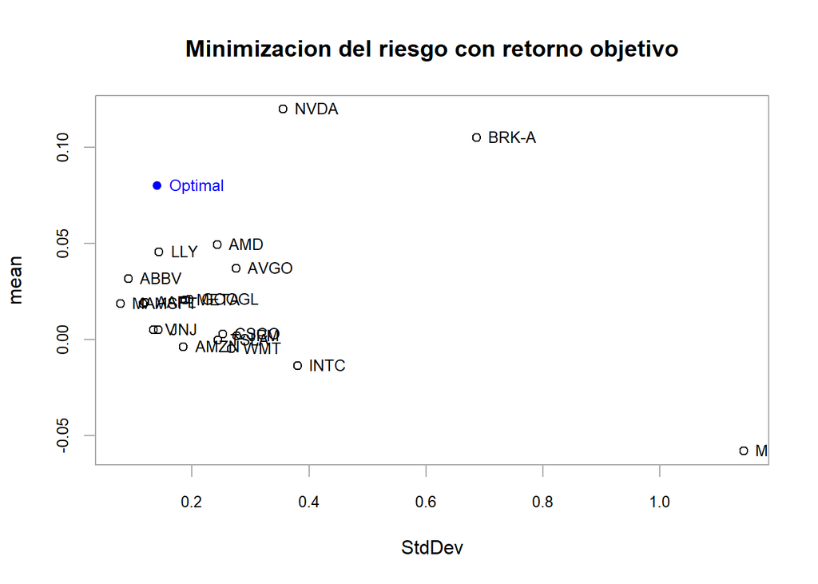

```r
PortfolioAnalytics::chart.RiskReward(opt.sd.return,
                                     risk.col = "StdDev",
                                     return.col = "mean",
                                     chart.assets = TRUE,
                                     rp = F,
                                     main = "Minimizacion del riesgo con retorno objetivo")
```

Esto es exactamente un punto sobre la frontera eficiente — se fija el retorno (8% en este caso) y se busca el portafolio de menor riesgo que lo alcance.

## 5.4 — Maximizar el Sharpe Ratio

```r
sr.portfolio <- PortfolioAnalytics::add.objective(portfolio = init.portfolio,
                                                    type = "risk",
                                                    name = "StdDev")
sr.portfolio <- PortfolioAnalytics::add.objective(portfolio = sr.portfolio,
                                                    type = "return",
                                                    name = "mean")

opt.sr <- PortfolioAnalytics::optimize.portfolio(R = retornos_mes,
                                                 portfolio = sr.portfolio,
                                                 optimize_method = "ROI",
                                                 trace = T,
                                                 maxSR = TRUE)
opt.sr
```

```
## PortfolioAnalytics Optimization
##
## Call:
## PortfolioAnalytics::optimize.portfolio(R = retornos_mes, portfolio = sr.portfolio,
##     optimize_method = "ROI", trace = T, maxSR = TRUE)
##
## Optimal Weights:
##   NVDA   AAPL  GOOGL   MSFT   AMZN   AVGO   META   TSLA    LLY  BRK-A     MU
## 0.0597 0.0000 0.0000 0.0000 0.0000 0.1342 0.0000 0.0000 0.2188 0.1750 0.0174
##    JPM    WMT    AMD      V    JNJ     MA   INTC   ABBV   CSCO
## 0.0755 0.1489 0.0000 0.0000 0.0000 0.0000 0.0000 0.1704 0.0000
##
## Objective Measure:
##  StdDev
## 0.05847
##
##
##    mean
## 0.04429
```

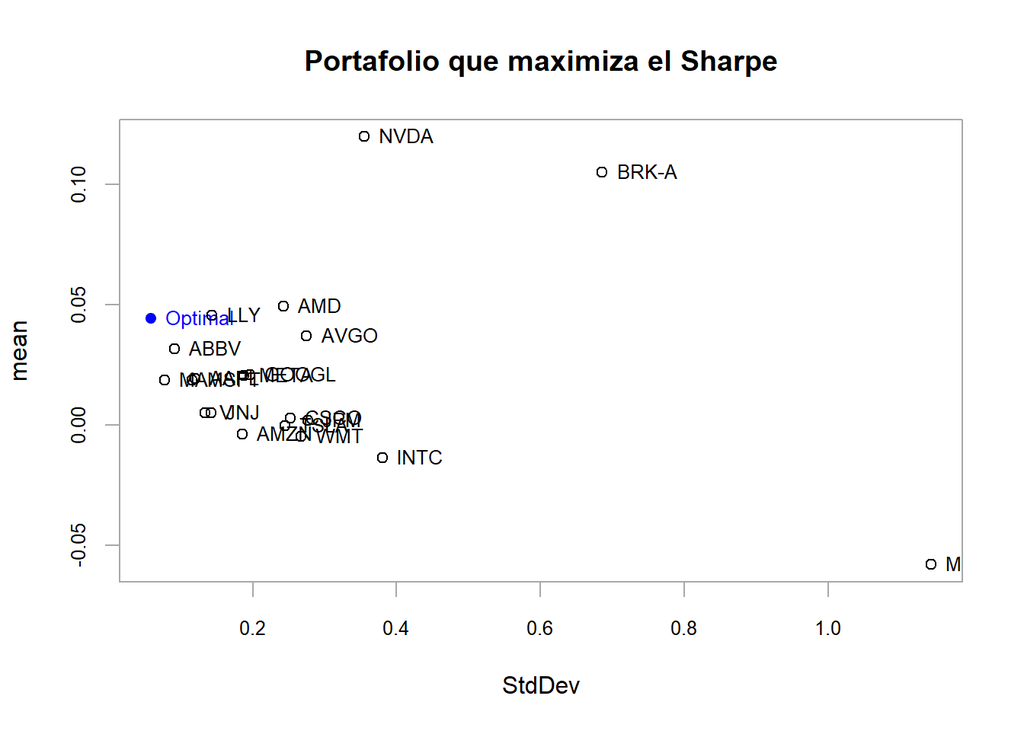

```r
PortfolioAnalytics::chart.RiskReward(opt.sr,
                                     risk.col = "StdDev",
                                     return.col = "mean",
                                     chart.assets = TRUE,
                                     rp = F,
                                     main = "Portafolio que maximiza el Sharpe")
```

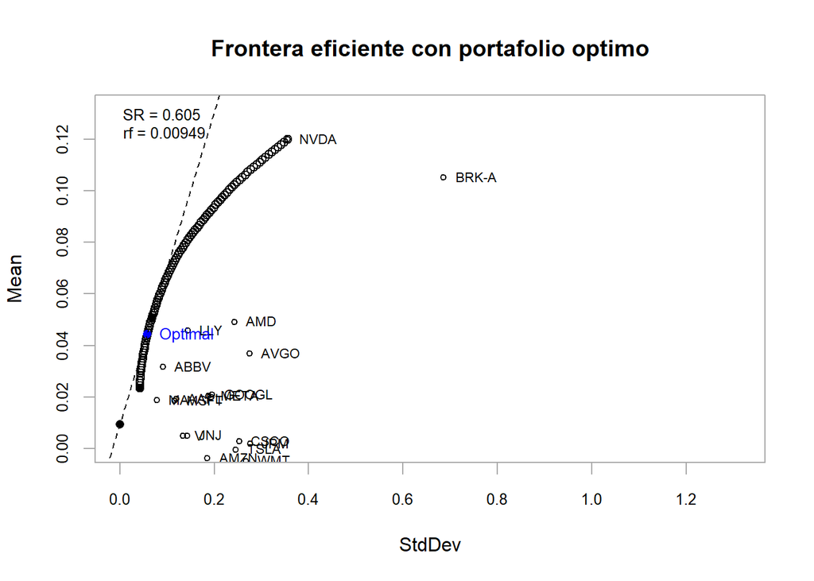

```r
PortfolioAnalytics::chart.EfficientFrontier(opt.sr,
                                            match.col = 'StdDev',
                                            main = "Frontera eficiente con portafolio optimo",
                                            cex.assets = 0.7,
                                            tangent.line = T,
                                            n.portfolios = 100,
                                            rf = free_rate)
```

## Pesos del portafolio óptimo (máximo Sharpe)

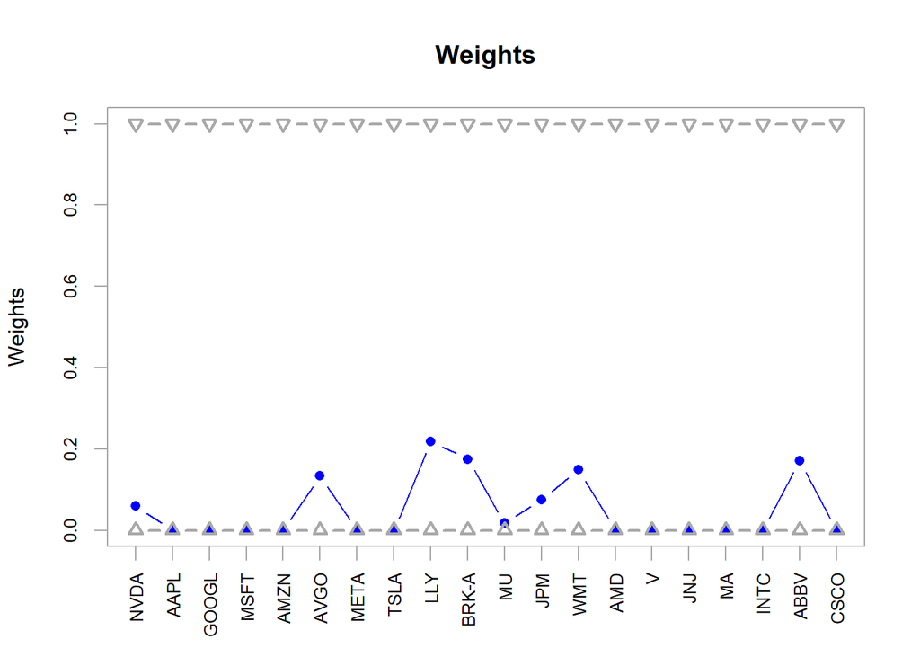

```r
chart.Weights(opt.sr)
```

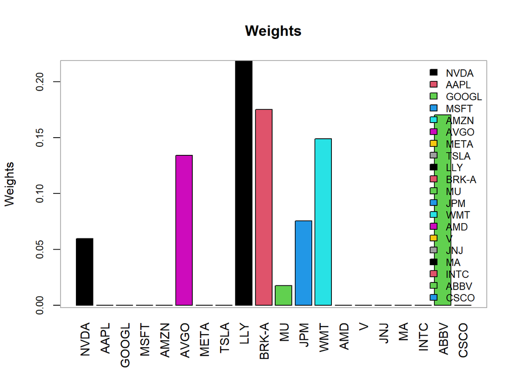

```r
chart.Weights(opt.sr, plot.type = "barplot")
```

## Diversificación

**Qué hace**: dos medidas resumen qué tan repartido queda el capital entre activos.

**Por qué (teoría)**:

- **`diversification()`** — a mayor número, mejor diversificación (más repartido).
- **`HHI()`** (Índice Herfindahl-Hirschman, el mismo que se usa para medir concentración de mercado en organización industrial) — a mayor número, más concentración en pocos activos. Un portafolio con todo el peso en un solo activo tiene HHI = 1 (concentración máxima); repartido en partes iguales entre *N* activos, HHI = 1/*N*.

```r
diversification(weights = opt.sr$weights)
```

```
## [1] 0.8426844
```

```r
HHI(weights = opt.sr$weights)
```

```
## [1] 0.1573156
```

## Comparación de Sharpe Ratios

```r
data.frame(
  estrategia = c("Igual peso (implícito)", "Máximo retorno", "Mínimo riesgo",
                 "Mínimo riesgo, retorno objetivo", "Máximo Sharpe"),
  sharpe = c(
    NA,
    as.numeric(SharpeRatio(R = retornos_mes, Rf = 0, weights = opt.mean$weights, FUN = "StdDev")),
    as.numeric(SharpeRatio(R = retornos_mes, Rf = 0, weights = opt.sd$weights, FUN = "StdDev")),
    as.numeric(SharpeRatio(R = retornos_mes, Rf = 0, weights = opt.sd.return$weights, FUN = "StdDev")),
    as.numeric(SharpeRatio(R = retornos_mes, Rf = 0, weights = opt.sr$weights, FUN = "StdDev"))
  )
)
```

| estrategia | sharpe |
| --- | --- |
| Igual peso (implícito) | NA |
| Máximo retorno | 0.3369583 |
| Mínimo riesgo | 0.5523095 |
| Mínimo riesgo, retorno objetivo | 0.5680435 |
| Máximo Sharpe | 0.7574718 |

El objetivo que explícitamente maximiza el Sharpe Ratio (`maxSR = TRUE`) da, por construcción, el Sharpe más alto de los cuatro — los otros tres resuelven un problema distinto (mínima varianza, máximo retorno, retorno objetivo) y solo coinciden con el máximo Sharpe por casualidad.

# Parte 6 — Restricción de pesos máximos (`box constraint`)

**Qué hace**: repite el mismo ejercicio (frontera eficiente + máximo Sharpe), pero ahora con un límite explícito de **máximo 30% del capital en cualquier activo individual**.

**Por qué (teoría)**: en la práctica, ni los reguladores ni la política de riesgo de un fondo suelen permitir que un solo activo domine el portafolio — aunque matemáticamente esa fuera la solución óptima sin restricciones. La restricción `box` (mínimo y máximo por activo) es la forma estándar de imponer límites de concentración sin cambiar el resto del problema de optimización.

```r
box.portfolio <- PortfolioAnalytics::add.constraint(portfolio = init.portfolio,
                                                  type = "box", min = 0, max = 0.3)
box.portfolio
```

```
## PortfolioAnalytics Portfolio Specification
##
## Call:
## PortfolioAnalytics::portfolio.spec(assets = activos, name = "Portafolio inicial")
##
## Number of assets: 20
## Asset Names
##  [1] "NVDA"  "AAPL"  "GOOGL" "MSFT"  "AMZN"  "AVGO"  "META"  "TSLA"  "LLY"
## [10] "BRK-A"
## More than 10 assets, only printing the first 10
##
## Constraints
## Enabled constraint types
##      - full_investment
##      - long_only
##      - box
```

```r
box.eff <- PortfolioAnalytics::create.EfficientFrontier(R = retornos_mes,
                                                            portfolio = box.portfolio,
                                                            type = 'mean-StdDev',
                                                            n.portfolios = 100)
box.eff
```

```
## PortfolioAnalytics Efficient Frontier
##
## Call:
## PortfolioAnalytics::create.EfficientFrontier(R = retornos_mes,
##     portfolio = box.portfolio, type = "mean-StdDev", n.portfolios = 100)
##
## Efficient Frontier Points: 100
##
## PortfolioAnalytics Portfolio Specification
##
## Call:
## PortfolioAnalytics::portfolio.spec(assets = activos, name = "Portafolio inicial")
##
## Number of assets: 20
## Asset Names
##  [1] "NVDA"  "AAPL"  "GOOGL" "MSFT"  "AMZN"  "AVGO"  "META"  "TSLA"  "LLY"
## [10] "BRK-A"
## More than 10 assets, only printing the first 10
##
## Constraints
## Enabled constraint types
##      - full_investment
##      - long_only
##      - box
```

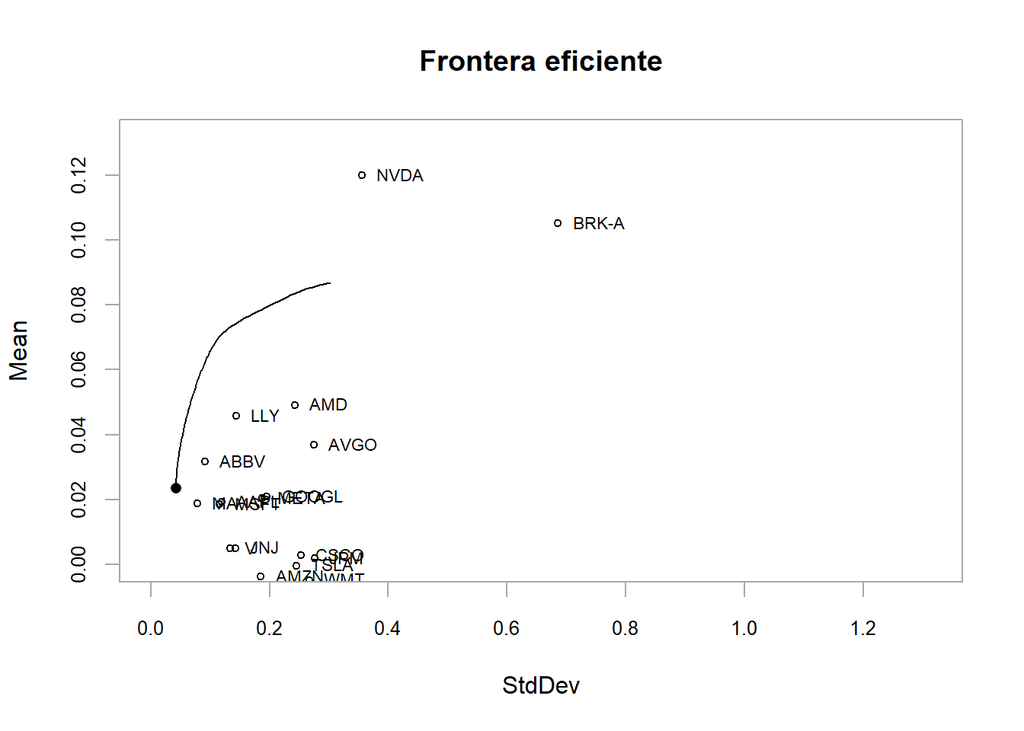

```r
PortfolioAnalytics::chart.EfficientFrontier(box.eff,
                                            match.col = 'StdDev',
                                            type = 'l',
                                            rf=NULL,
                                            main = "Frontera eficiente",
                                            cex.assets = 0.7)
```

```r
box.portfolio <- PortfolioAnalytics::add.objective(portfolio = box.portfolio,
                                                   type = "risk",
                                                   name = "StdDev")
box.portfolio <- PortfolioAnalytics::add.objective(portfolio = box.portfolio,
                                                   type = "return",
                                                   name = "mean")

opt.box.sr <- PortfolioAnalytics::optimize.portfolio(R = retornos_mes,
                                                  portfolio = box.portfolio,
                                                  optimize_method = "ROI",
                                                  trace = T,
                                                  maxSR = TRUE)
opt.box.sr
```

```
## PortfolioAnalytics Optimization
##
## Call:
## PortfolioAnalytics::optimize.portfolio(R = retornos_mes, portfolio = box.portfolio,
##     optimize_method = "ROI", trace = T, maxSR = TRUE)
##
## Optimal Weights:
##   NVDA   AAPL  GOOGL   MSFT   AMZN   AVGO   META   TSLA    LLY  BRK-A     MU
## 0.0597 0.0000 0.0000 0.0000 0.0000 0.1342 0.0000 0.0000 0.2188 0.1750 0.0174
##    JPM    WMT    AMD      V    JNJ     MA   INTC   ABBV   CSCO
## 0.0755 0.1489 0.0000 0.0000 0.0000 0.0000 0.0000 0.1704 0.0000
##
## Objective Measure:
##  StdDev
## 0.05847
##
##
##    mean
## 0.04429
```

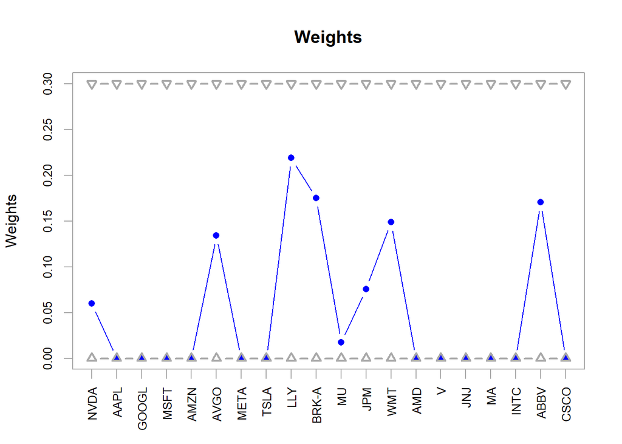

```r
chart.Weights(opt.box.sr)
```

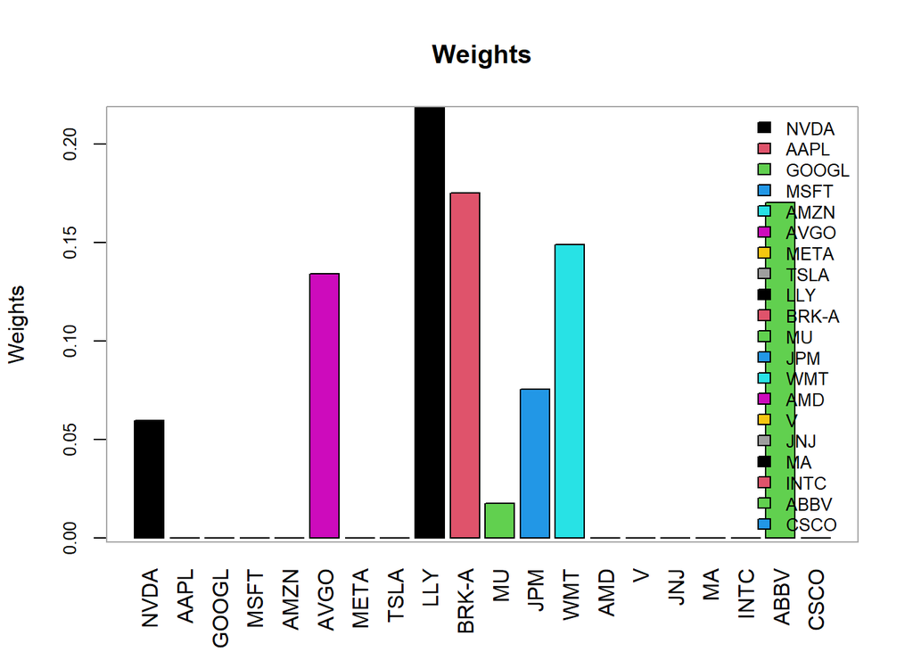

```r
chart.Weights(opt.box.sr, plot.type = "barplot")
```

```r
diversification(weights = opt.box.sr$weights)
```

```
## [1] 0.8426844
```

```r
HHI(weights = opt.box.sr$weights)
```

```
## [1] 0.1573156
```

## Costo de la restricción, en Sharpe Ratio

```r
data.frame(
  estrategia = c("Máximo Sharpe (sin límite de peso)", "Máximo Sharpe (máx. 30% por activo)"),
  sharpe = c(
    as.numeric(SharpeRatio(R = retornos_mes, Rf = 0, weights = opt.sr$weights, FUN = "StdDev")),
    as.numeric(SharpeRatio(R = retornos_mes, Rf = 0, weights = opt.box.sr$weights, FUN = "StdDev"))
  )
)
```

| estrategia | sharpe |
| --- | --- |
| Máximo Sharpe (sin límite de peso) | 0.7574718 |
| Máximo Sharpe (máx. 30% por activo) | 0.7574718 |

Toda restricción adicional (aquí, el límite de concentración) solo puede **empeorar o igualar** el Sharpe del óptimo sin restringir — nunca mejorarlo, porque se está buscando la mejor solución dentro de un conjunto de opciones más chico. La pregunta relevante en la práctica no es “¿por qué bajó el Sharpe?”, sino si el costo en Sharpe vale la pena por el beneficio de un portafolio menos concentrado y más fácil de justificar frente a un comité de riesgo.